# Vignette Final Deliverable

Author

Meg Norten, Sarah Fischer, Alyssa Langmeyer, Elizabeth-Lynda Nartey

Published

December 5, 2025

# Background

> Cyber security vulnerabilities have increased significantly in recent years as digital systems have become more interconnected and reliant on complex software ecosystems. According to the U.S. Department of State (n.d.), “in 2020 alone, the FBI estimated more than $4 billion was lost to cyber crime in the United States” (para. 1). Common forms of cyber attacks include ransom-ware, phishing and spear-phishing, and denial-of-service (DoS/DDoS) attacks, among others (SentinelOne, n.d.). The consequences of cyber attacks extend far beyond financial loss, affecting national security, critical infrastructure, and global supply chains. Sectors such as healthcare, education, finance, and government (including military operations) face particularly elevated levels of risk. The continuing rise in cyber threats motivated the development of the Cyber Vulnerabilities Outlook Dashboard, which provides an interactive tool for exploring global patterns in cyber vulnerabilities and generating insights to support threat assessment and mitigation.

# Use Case

> The Cyber Vulnerabilities Outlook Dashboard is designed to provide rapid insights into the extent to which countries around the world experience cyber vulnerabilities and the factors that contribute to their severity. Users can interact with the dashboard to generate visualizations summarizing global vulnerability patterns and run statistical models to examine relationships among factors such as privileges required, product types, exploitability scores, and severity levels.

> The primary users of this application are United States national security advisers and analysts. Because U.S. national security professionals must continuously monitor emerging threats, understanding both domestic and global cyber vulnerabilities has become an increasingly critical task. Many recent national security challenges are cyber in nature, and identifying the characteristics of vulnerabilities across systems, vendors, and countries enables analysts to recommend targeted improvements to strengthen national cyber defenses. These users interact with the Shiny application interface to visualize international distributions of cyber vulnerabilities, assess trends, and identify technical or geographic risk factors that require attention.

> The design of the dashboard helps users address several core questions: (1) Which countries are most affected by cyber vulnerabilities, as reflected by mean impact scores mapped across the world? (2) Which system components, or “parts,” such as applications, operating systems, or hardware, exhibit the highest impact scores based on related characteristics including vendor, country, product, and year (3) How are exploitability scores related to impact scores, as assessed through a combination of scatterplots, correlation analyses, and ANOVA, all of which can be filtered by year, vendor, product, severity, and attack type? Collectively, these features support informed decision-making and help guide strategic investments in national cyber defense.

# Required Packages

> The development of the Cyber Vulnerabilities Outlook Dashboard required two major stages of package use: obtaining and preparing the vulnerability data, and constructing the interactive Shiny application. To collect and process the raw data from the National Vulnerability Database API, we used the httr2, keyring, jsonlite, and tidyverse packages. The httr2 package allowed us to perform authenticated requests to the NVD API, while keyring was used to securely store and retrieve the API key in a reproducible manner. The jsonlite package enabled efficient parsing of the JSON-formatted API responses into R data structures suitable for analysis. The tidyverse collection was essential during data cleaning, providing tools for importing, transforming, and reshaping the data through packages such as dplyr for manipulation, stringr for string processing, purrr for functions, and tibble for modern data frame handling. After processing the raw data, we saved a cleaned dataset (nvd_df.rds), which served as the foundation for all analyses in the dashboard.

> The second stage of development involved building the interactive application, which relied on an additional set of packages. The shiny package served as the core framework for the web application, allowing the dashboard to run reactively and respond to user input. To ensure a clean and cohesive visual theme, we incorporated bslib and thematic, which provide Bootstrap 5 styling and automatic plot theming. The tidyverse was again central to structuring analytical tasks and generating visualizations through ggplot2. For interactive data tables, we used DT, enabling users to sort, filter, and explore large volumes of vulnerability records. To produce the geographic components of the dashboard, we relied on rnaturalearth, rnaturalearthdata, sf, tmap, and leaflet. These packages allowed us to import global country boundaries, build spatial data structures, and render both static and interactive maps summarizing mean impact scores across countries. Together, all of these packages formed the foundation that supported secure data, reproducible processing, modern visualization, and a fully interactive Shiny web application. Each package played a necessary role in ensuring the dashboard performed efficiently, displayed information clearly, and delivered an accessible platform for exploring global cyber vulnerability trends.

# Data Source

> The default data source for our analysis is the National Vulnerability Database (NVD) API, which provides detailed information on cyber security vulnerabilities over time. After determining that the Shodan API required paid access and that the KEV catalog was not needed because the NVD API already supplied year-level data, we used only the NVD data to construct our final dataset. From the NVD API, we extracted key variables including cve_id, vendor, product, part type (application, hardware, or operating system), vendor_country, exploitability_score, impact_score, base_severity, and year_published, along with additional descriptive fields such as publication dates and vulnerability status. Because vendor_country is not provided directly by the API, we identified the country for the top 500 vendors based on their official websites and labeled any remaining cases or missing information as “Unknown.” The final dataset contains 303,522 observations and 22 variables, representing vulnerabilities from 1988 to 2025. These observations form the foundation of our Shiny App and support all exploratory and statistical analyses focused on understanding patterns across countries, vendors, products, and vulnerability severity characteristics.

# EDA Inputs, Controls, and Outputs

> The Exploratory Data Analysis section of the dashboard guides users through a simple, step-by-step workflow for exploring global cybersecurity vulnerabilities. Each visualization allows the user to filter or examine different aspects of the data and then interpret what the results mean. The workflow begins with a global geographic overview and progresses to part-level comparisons and finally to a relationship analysis using a scatterplot.

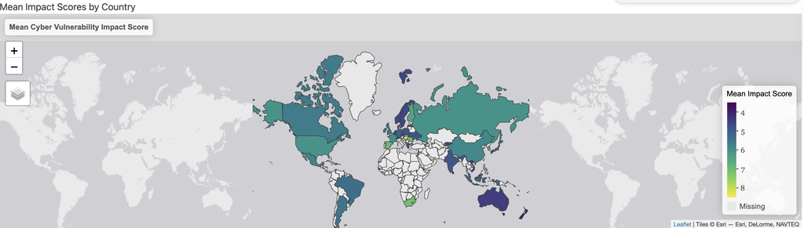

Figure 1: Mean cyber vulnerability impact scores by country as displayed in the Country Impact Scores Map.

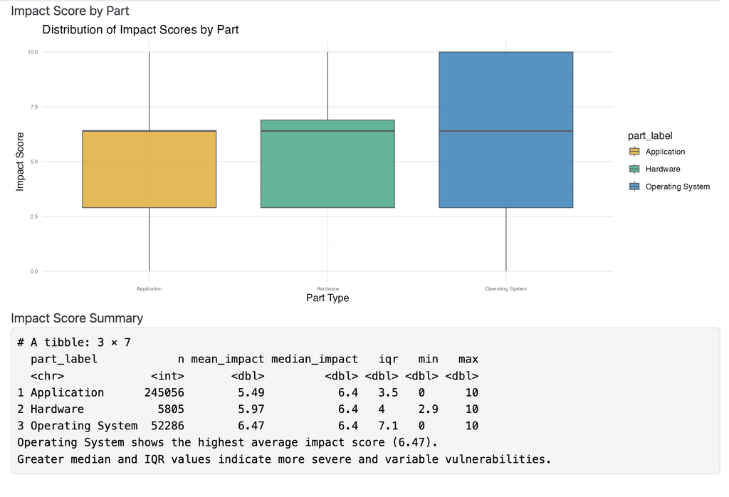

Figure 2: Distribution of impact scores across applications, operating systems, and hardware based on selected filters.

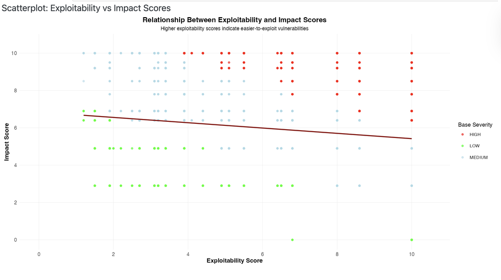

Figure 3: Scatterplot of exploitability and impact scores, with optional trend line based on user filters.

> All together these three visualizations guide the user through a clear and logical exploratory process. The map provides a global understanding of where vulnerabilities are most severe. The boxplot shows how different system parts contribute to impact levels. The scatterplot reveals relationships between exploitability and impact that help identify high-risk patterns. By moving from broad global patterns to specific analytical relationships, the user can answer a wide range of cybersecurity questions in a structured and interpretable way.

# Statistical Analysis Inputs, Controls, and Outputs

> The Statistical Analysis section of the dashboard allows users to move beyond visual exploration and conduct formal statistical testing on cyber vulnerability patterns. This section uses the same filtering controls as the boxplot and scatterplot tools, which include year, country, vendor, part, and product. These filters determine which subset of the data is used for each statistical analysis. The workflow provides two primary analytical tools: a correlation analysis and an ANOVA comparison. Together, these tools help users understand whether there are meaningful relationships or differences in vulnerability characteristics across system types, vendors, and time periods.

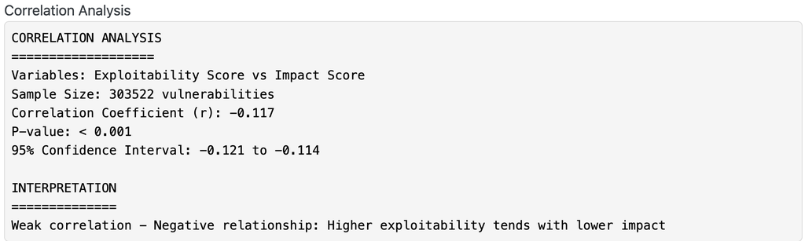

Figure 4: Correlation Analysis of Exploitability Score vs Impact Score.

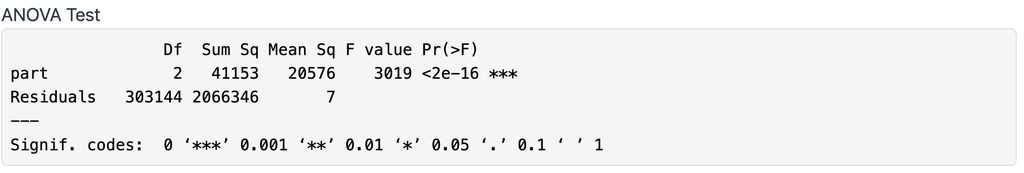

Figure 5: ANOVA Test by Parts.

> Together, the correlation analysis and ANOVA provide a structured workflow for conducting statistical evaluations of cybersecurity risk. Users can investigate how exploitability relates to impact, whether certain system parts experience higher severity, and whether patterns vary by vendor, product type, or country. By applying filters and examining analytical outputs, users can answer core questions such as which vendors produce the highest risk vulnerabilities, which parts show the most concerning trends, and how these patterns have evolved across time. This workflow provides clear and interpretable statistical evidence that supports deeper understanding of global cyber vulnerability patterns.

# Literature Review

> A review of existing literature on cyber vulnerabilities highlights the importance of understanding and addressing cyber threats on a national and international scale. The research highlights the reality of vulnerability life cycles, the limitations of existing public metrics, and the strategic importance of synthesizing disparate data sources for national security prioritization, all of which inform our app concept.

### Source 1: Trend Analysis of the CVE Classes Across CVSS Metrics

> **Citation:** Dodiya, B., Singh, U. K., & Gupta, V. (2021). Trend Analysis of the CVE Classes Across CVSS Metrics. International Journal of Computer Applications, 183(33), 23-30.

> **Takeaways:** The study provides a proven framework for longitudinal analysis of the National Vulnerability Database (NVD), validating our app’s core approach of using CVE records and CVSS metrics to track cyber security trends. It establishes that the cybersecurity landscape is inherently high-risk, with over 90% of vulnerabilities rated Medium, High, or Critical severity.

> **Project Relevance:** This justifies our app’s focus on helping users triage and prioritize serious threats. The detailed analysis of CVSS base metrics (e.g., Access Vector, Complexity, CIA Impact) offers a direct blueprint for the interactive filters and charts in our Shiny app, ensuring we highlight the most operationally relevant dimensions of the data.

### Source 2: Conflicting Scores, Confusing Signals: An Empirical Study of Vulnerability Scoring Systems

> **Citation:** Koscinski, V., Nelson, M., Okutan, A., Falso, R., & Mirakhorli, M. (2025). Conflicting Scores, Confusing Signals: An Empirical Study of Vulnerability Scoring Systems. In Proceedings of the 32nd ACM Conference on Computer and Communications Security (CCS).

> **Takeaways:** This paper identifies a fundamental problem in vulnerability management: conflicting signals from different scoring systems (CVSS, EPSS, SSVC) complicate prioritization for security teams. Our project’s design directly addresses this challenge. The study empirically demonstrates that these systems show very low agreement and often rank the same vulnerabilities differently. Crucially, it finds that predictive models like EPSS frequently fail to flag vulnerabilities before they are actively exploited, as recorded in the CISA KEV catalog.

### Source 3: The Geopolitics of Cybersecurity: A Comparative Analysis of National Strategies for Digital Sovereignty

> **Citation:** Prokopyshyn, O., & Trushkina, N. (2025). The geopolitics of cybersecurity: A comparative analysis of national strategies for digital sovereignty. Politics & Security, 12(2), 59–71.

> **Takeaways:** This paper establishes that cyberspace is a primary domain of 21st-century geopolitical competition, where nations like the US, EU, China, and Russia are pursuing “digital sovereignty” through distinct and often conflicting strategies. The analysis reveals a global trend towards a fragmented “splinternet,” where national security is directly tied to controlling digital infrastructure and mitigating vulnerabilities to foreign manipulation.

> **Project Relevance:** Our project’s focus on mapping international cyber vulnerabilities is situated within this high-stakes context. For a national security actor, understanding the geographic distribution of exploited vulnerabilities is not a technical exercise, but a strategic imperative to assess the cyber threat landscape, identify potential adversaries’ capabilities, and inform foreign and defense policy. Our app provides the data-driven situational awareness required to navigate this new era of digital statecraft.

# References

> U.S. Department of State. (n.d.). *Combatting cybercrime*. https://www.state.gov/cybercrime

> SentinelOne. (n.d.). *Cyber attacks in the United States: Trends and statistics*. https://www.sentinelone.com/cybersecurity-101/cybersecurity/cyber-attacks-in-the-united-states/